# HW6: Textual Analysis

Will Fleischer

April 20, 2023

```r
trees = read_csv("C:/Users/wfly/OneDrive - University of North Carolina at Chapel Hill/Desktop/PLAN 372/RDS-2016-0005/Data/TS3_Raw_tree_data.csv")
```

# Question 1:

The dataset does not contain a state column, but does contain a city column which contains both city and state information (e.g. Charlotte, NC). Use a regular expression to create separate columns for the city name and state abbreviation, and use these columns to answer the following questions.

How many records are there in each state (include a table or bar plot)? [3 points]

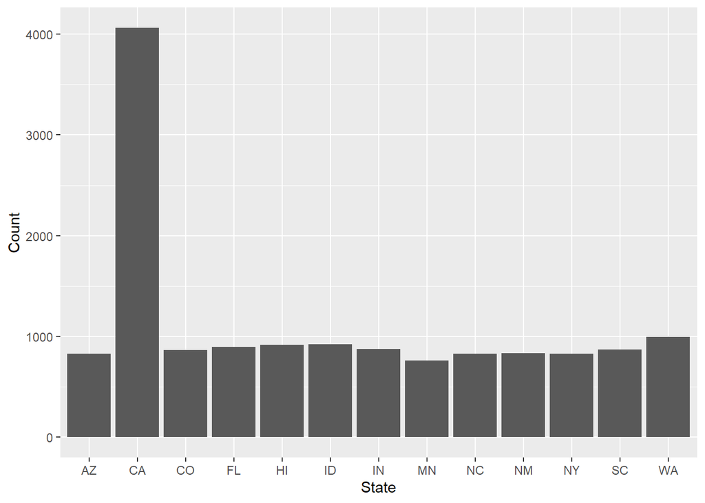

```r
# matching with two alphanumeric values after a comma to retrieve state
trees$State = str_match(trees$City, ", [:alnum:][:alnum:]")
# removing the comma and space afterwards
trees$State = str_match(trees$State, "[:alnum:][:alnum:]")

# separating city by removing state, using what we did to extract state
trees$City = str_replace(trees$City, ", [:alnum:][:alnum:]", "")

# count function to see number of trees per state
by_state = count(trees, State)

# using geom_col to represent count values in the data.
ggplot(by_state, aes(x = State, y = n,)) +
  geom_col() + ylab("Count")
```

# Question 2:

Since different trees grow differently in different parts of the country, the city wants you to only use data from North and South Carolina. Filter the dataset to only these states, and use that filtered dataset for all remaining questions.

What cities did they collect data from in North and South Carolina? [1 point]

**The collected data is from Charleston and Charlotte**

```r
# filtering by NC and SC
carolinas = filter(trees, State == "NC" | State == "SC")
# Seeing which cities are represented by using the unique function
unique(carolinas$City)
```

```
## [1] "Charleston" "Charlotte"
```

# Question 3: Genera and species

The city wishes to know what types of trees in the dataset have the largest crown (i.e. their branches and leaves cover the most area, maximizing shade). The crown size is in the column AvgCdia (m), in meters.

The data contain the scientific names of the species of each surveyed tree. Scientific names use binomial nomenclature, where the scientific names contain both a genus (plural genera) and species. For instance, Acer saccharumLinks to an external site. is the sugar maple; the genus is Acer and the species is saccharum. Trees within a genus are related and may share physical characteristics. For instance, Acer rubrumLinks to an external site. or the red maple is another large maple tree. To maximize sample size, the city has requested you compute the average canopy diameter for each genus. This requires you to write a regular expression to extract the genus.

What genus of trees has the largest crown diameter in North and South Carolina? [2 points]

**The genus of tree with the larges crown diameter in the Carolinas is the Quercus.**

```r
# seeing which scientific names are represented
unique(carolinas$ScientificName)
```

```
##  [1] "Ilex opaca"              "Celtis laevigata"
##  [3] "Quercus virginiana"      "Acer rubrum"
##  [5] "Butia capitata"          "Carya illinoinensis"
##  [7] "Liquidambar styraciflua" "Lagerstroemia indica"
##  [9] "Sabal palmetto"          "Platanus occidentalis"
## [11] "Quercus laurifolia"      "Magnolia grandiflora"
## [13] "Quercus nigra"           "Cornus florida"
## [15] "Juniperus virginiana"    "Pinus taeda"
## [17] "Pyrus calleryana"        "Gleditsia triacanthos"
## [19] "Quercus phellos"         "Quercus alba"
## [21] "Quercus rubra"           "Lagerstroemia sp."
## [23] "Pinus echinata"          "Prunus yedoensis"
## [25] "Acer saccharum"          "Acer saccharinum"
## [27] "Ulmus alata"             "Malus sp."
## [29] "Prunus sp."              "Betula nigra"
```

```r
# separating the genus from the species
carolinas$Genus = str_match(carolinas$ScientificName, "^[:alnum:]+[:space:]")
# removing a space left at the end of the genus values
carolinas$Genus = substr(carolinas$Genus, 1, nchar(carolinas$Genus)-1)

# grouping by genus and summarizing by mean crown size
by_genus = group_by(carolinas, Genus)
average_by_genus = summarize(by_genus, average_crown = mean(`AvgCdia (m)`), na.rm = TRUE)

# showing the five highest values
head(arrange(average_by_genus, desc(average_crown)),5)
```

```
## # A tibble: 5 × 3
##   Genus[,1] average_crown na.rm
##   <chr>             <dbl> <lgl>
## 1 Quercus            13.6 TRUE
## 2 Platanus           12.0 TRUE
## 3 Acer               11.5 TRUE
## 4 Carya              10.5 TRUE
## 5 Betula             10.4 TRUE
```

# Extra Credit:

# Tree Age

Older trees, of course, have larger crowns. Are there differences in the average age of the different genera of trees in the dataset? Might this explain the results of the previous question? [1 point]

**The Quercus genus has a significantly higher average age than any other genus, which is likely why it is the genus with the largest crowns on average**

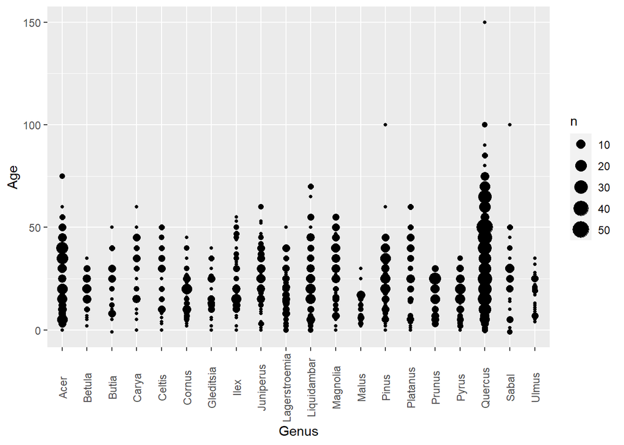

```r
ggplot(carolinas, mapping = aes(x = Genus, y = Age)) +
  geom_count() + theme(axis.text.x = element_text(angle = 90, vjust = 0.5))
```

Recommend a genera that produces a large crown quickly (among trees in North and South Carolina). You can use any analytical methods you want (group by, plots, linear regression, etc.). Document the process by which you chose this type of tree. [2 points]

**For trees within the first quartile in age of all trees in the Carolinas, the tree that produces the largest crowns on average is the Gleditsia genus, with an average crown size of 6.47.**

```r
# finding spread of data, will look at trees with ages at or below the value for the first quartile to determine our quick criteria
first_quartile = summary(carolinas$Age)[2]

# creating new dataset where age is at or below the first quartile
quick = filter(carolinas, Age <= first_quartile)


quick_by_genus = group_by(quick, Genus)
quick_average = summarize(quick_by_genus, average_crown = mean(`AvgCdia (m)`), na.rm = TRUE)
head(arrange(quick_average, desc(average_crown)),5)
```

```
## # A tibble: 5 × 3
##   Genus[,1] average_crown na.rm
##   <chr>             <dbl> <lgl>
## 1 Gleditsia          6.47 TRUE
## 2 Prunus             5.72 TRUE
## 3 Ulmus              5.22 TRUE
## 4 Quercus            4.82 TRUE
## 5 Betula             4.76 TRUE
```

# Species

So far, all of the analysis has focused on genera. Refine your regular expression to also extract the species as well, as a separate column. Within each genus of tree in North and South Carolina, how many species are recorded in the dataset? [2 points]

```r
# ensuring additional criteria in cases is met - luckily the method I used is able to account for these cases
unique(carolinas$ScientificName)
```

```
##  [1] "Ilex opaca"              "Celtis laevigata"
##  [3] "Quercus virginiana"      "Acer rubrum"
##  [5] "Butia capitata"          "Carya illinoinensis"
##  [7] "Liquidambar styraciflua" "Lagerstroemia indica"
##  [9] "Sabal palmetto"          "Platanus occidentalis"
## [11] "Quercus laurifolia"      "Magnolia grandiflora"
## [13] "Quercus nigra"           "Cornus florida"
## [15] "Juniperus virginiana"    "Pinus taeda"
## [17] "Pyrus calleryana"        "Gleditsia triacanthos"
## [19] "Quercus phellos"         "Quercus alba"
## [21] "Quercus rubra"           "Lagerstroemia sp."
## [23] "Pinus echinata"          "Prunus yedoensis"
## [25] "Acer saccharum"          "Acer saccharinum"
## [27] "Ulmus alata"             "Malus sp."
## [29] "Prunus sp."              "Betula nigra"
```

```r
# extracting species
carolinas$Species = str_match(carolinas$ScientificName, "[:space:]+[:alnum:]+")
# removing space at beginning
carolinas$Species = substring(carolinas$Species, 2)

# use count function to see how many trees of each species a genus has
count(carolinas, Genus, Species)
```

```
## # A tibble: 30 × 3
##    Genus[,1] Species[,1]       n
##    <chr>     <chr>         <int>
##  1 Acer      rubrum           80
##  2 Acer      saccharinum      48
##  3 Acer      saccharum        41
##  4 Betula    nigra            39
##  5 Butia     capitata         33
##  6 Carya     illinoinensis    36
##  7 Celtis    laevigata        37
##  8 Cornus    florida          68
##  9 Gleditsia triacanthos      37
## 10 Ilex      opaca            71
## # … with 20 more rows
```